# APRENDIZADO DE MÁQUINA

Lucas Pereira Belo

2026-06-14

Este relatório apresenta o desenvolvimento e a avaliação de modelos preditivos aplicados a um experimento com cana-de-açúcar conducted sob o Delineamento em Blocos Casualizados (DBC) na estação experimental de Oratórios, MG. O estudo avalia 60 famílias distribuídas em 4 blocos (repetições), totalizando 240 parcelas experimentais. Os dados originais foram sumarizados ao nível de média por família no arquivo dd3.xlsx, totalizando 60 entradas analíticas.

O objetivo central é praticar e comparar técnicas de aprendizado estatístico para problemas de Regressão e Classificação:

Problema de Regressão: Predizer a produtividade contínua das famílias, mensurada em Toneladas de Colmos por Hectare (TSH), visando identificar e selecionar os materiais genéticos mais produtivos antes da pesagem física massiva no campo.

Problema de Classificação: Predizer a classe de rendimento da família (TSH_class), segregada a partir da média geral do experimento, avaliando a acurácia de modelos supervisionados na triagem dicotômica.

```r
dd3 <- read_excel("dd3.xlsx")

dados <- dd3 %>%
  select(
    Family = Familia,
    SN     = NC,        # Número médio de colmos por parcela
    TSH    = TCH.x,     # Toneladas de colmos por hectare
    SD     = DIAMETRO,  # Diâmetro médio do colmo
    SH     = ALTURA,    # Altura média do colmo
    R      = Red,       # Reflectância na banda do Vermelho
    G      = Green,     # Reflectância na banda do Verde
    B      = Blue,      # Reflectância na banda do Azul
    VARI   = VARI,      # Visible Atmospherically Resistant Index
    GLI    = GLI,       # Green Leaf Index
    NGRDI  = NGRDI      # Normalized Green Red Difference Index
  )

dados$Family <- as.factor(dados$Family)
summary(dados %>% select(-Family))
```

```
##        SN             TSH               SD              SH
##  Min.   :4.774   Min.   : 54.27   Min.   :20.17   Min.   :1.699
##  1st Qu.:6.300   1st Qu.:106.30   1st Qu.:23.44   1st Qu.:2.033
##  Median :7.023   Median :119.27   Median :24.26   Median :2.185
##  Mean   :7.049   Mean   :119.09   Mean   :24.21   Mean   :2.136
##  3rd Qu.:7.721   3rd Qu.:136.29   3rd Qu.:25.38   3rd Qu.:2.307
##  Max.   :9.680   Max.   :167.32   Max.   :27.42   Max.   :2.460
##        R                G               B              VARI
##  Min.   : 74.44   Min.   :78.21   Min.   :71.38   Min.   :-0.108724
##  1st Qu.: 84.58   1st Qu.:83.18   1st Qu.:80.88   1st Qu.:-0.041096
##  Median : 88.08   Median :86.23   Median :83.17   Median :-0.026263
##  Mean   : 88.70   Mean   :85.84   Mean   :83.51   Mean   :-0.027964
##  3rd Qu.: 91.08   3rd Qu.:88.04   3rd Qu.:85.35   3rd Qu.:-0.006795
##  Max.   :108.59   Max.   :96.53   Max.   :97.49   Max.   : 0.047356
##       GLI                 NGRDI
##  Min.   :-0.0317192   Min.   :-0.057194
##  1st Qu.:-0.0080239   1st Qu.:-0.021791
##  Median : 0.0005296   Median :-0.013783
##  Mean   :-0.0006298   Mean   :-0.014769
##  3rd Qu.: 0.0085262   3rd Qu.:-0.003765
##  Max.   : 0.0353519   Max.   : 0.025050
```

Para diagnosticar a estrutura de associação linear entre os preditores e a variável resposta, gerou-se a matriz de correlação gráfica de Pearson focada nas variáveis espectrais e na produtividade.

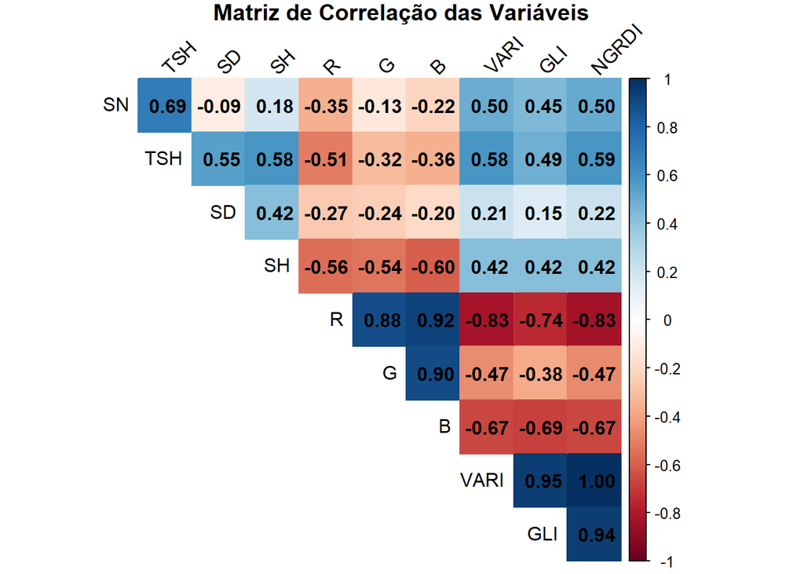

```r
dados_num <- dados %>% select(-Family)
matriz_corr <- cor(dados_num, use = "complete.obs")

# Plota a matriz de correlação de forma bem visual e profissional
corrplot(matriz_corr,
         method = "color",       # Usa cores para representar a força
         type = "upper",         # Mostra só a metade de cima da matriz
         addCoef.col = "black",  # Adiciona os números da correlação em preto
         tl.col = "black",       # Cor do texto dos eixos
         tl.srt = 45,            # Rotaciona os nomes das variáveis em 45 graus
         diag = FALSE,           # Tira a diagonal principal (que é sempre 1)
         title = "Matriz de Correlação das Variáveis",
         mar = c(0,0,1,0))       # Ajusta a margem para o título caber direitinho
```

Ajustou-se inicialmente um modelo linear de mínimos quadrados ordinários contendo todas as 9 covariáveis disponíveis para explicar o comportamento contínuo do TSH.

```r
lm.fit =lm(TSH~. -Family,data=dados )
summary (lm.fit)
```

```
##
## Call:
## lm(formula = TSH ~ . - Family, data = dados)
##
## Residuals:
##      Min       1Q   Median       3Q      Max
## -13.3225  -4.6598   0.0325   4.3193  18.5219
##
## Coefficients:
##               Estimate Std. Error t value Pr(>|t|)
## (Intercept)  -241.0510    67.7506  -3.558  0.00083 ***
## SN             14.2627     1.1217  12.715  < 2e-16 ***
## SD              7.3541     0.7578   9.705 4.36e-13 ***
## SH             28.5597     6.5013   4.393 5.82e-05 ***
## R               3.5302     6.9454   0.508  0.61349
## G              -5.3200    10.1599  -0.524  0.60285
## B               2.0935    16.0470   0.130  0.89673
## VARI          908.4688  2621.0912   0.347  0.73035
## GLI           181.4646  5303.7626   0.034  0.97284
## NGRDI       -1001.5408  8531.1345  -0.117  0.90701
## ---
## Signif. codes:  0 '***' 0.001 '**' 0.01 '*' 0.05 '.' 0.1 ' ' 1
##
## Residual standard error: 6.962 on 50 degrees of freedom
## Multiple R-squared:  0.9189, Adjusted R-squared:  0.9043
## F-statistic: 62.98 on 9 and 50 DF,  p-value: < 2.2e-16
```

```r
lm.fit2 =lm(TSH~ SN + SD + SH + G + GLI ,data=dados )
summary (lm.fit2)
```

```
##
## Call:
## lm(formula = TSH ~ SN + SD + SH + G + GLI, data = dados)
##
## Residuals:
##      Min       1Q   Median       3Q      Max
## -15.6396  -4.4651   0.6971   3.8180  21.1568
##
## Coefficients:
##              Estimate Std. Error t value Pr(>|t|)
## (Intercept) -246.4846    37.5007  -6.573 2.03e-08 ***
## SN            14.7567     1.0103  14.606  < 2e-16 ***
## SD             7.6663     0.7016  10.926 2.71e-15 ***
## SH            27.0910     5.9723   4.536 3.23e-05 ***
## G              0.2110     0.3188   0.662    0.511
## GLI           16.8767    89.6504   0.188    0.851
## ---
## Signif. codes:  0 '***' 0.001 '**' 0.01 '*' 0.05 '.' 0.1 ' ' 1
##
## Residual standard error: 7.227 on 54 degrees of freedom
## Multiple R-squared:  0.9057, Adjusted R-squared:  0.8969
## F-statistic: 103.7 on 5 and 54 DF,  p-value: < 2.2e-16
```

### Diagnóstico de Multicolinearidade (VIF)

Para atestar estatisticamente o excesso de colinearidade observado na matriz de correlação, calculou-se o Fator de Inflação da Variância (VIF) para o modelo completo utilizando o pacote `car`.

```r
library(car)

# Calculando o VIF do modelo completo
valores_vif <- vif(lm.fit)

# Exibindo os valores de forma organizada
print(valores_vif)
```

```
##           SN           SD           SH            R            G            B
##     1.730188     1.591757     2.238780  2113.287030  1604.761828  5386.548391
##         VARI          GLI        NGRDI
##  9414.667615  5788.694146 27366.037477
```

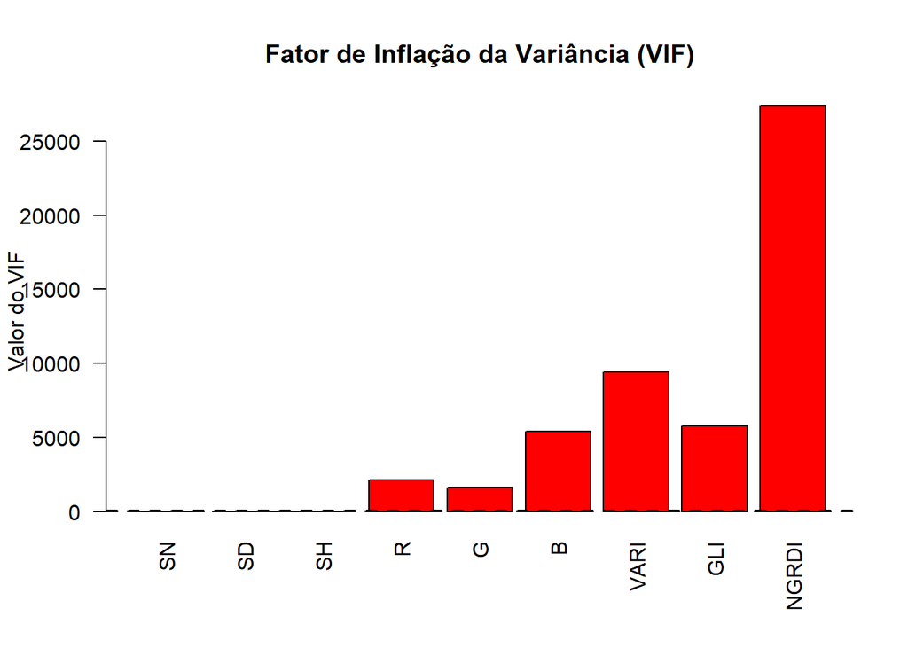

```r
# BÔNUS: Gráfico de barras para ilustrar a gravidade do VIF
barplot(valores_vif,
        main = "Fator de Inflação da Variância (VIF)",
        col = ifelse(valores_vif > 10, "red", "steelblue"),
        las = 2,
        ylab = "Valor do VIF")
abline(h = 10, col = "black", lty = 2, lwd = 2)
```

Os elevados valores do VIF indicam uma multicolinearidade severa, esses achados conjutamente do grafico de correlação indicam que o modelo contendo todas as variáveis se mostra inadequado. Esses indicativos sugerem que devemos utilizar métodos de reduçãod e dimensionalidade para reduzir a multicolinearidade presente nos dados.

Para a construção do modelo PCR, todas as 9 covariáveis preditoras foram submetidas à Análise de Componentes Principais. Como as variáveis originais possuem diferentes unidades de medida (contagens, centímetros, porcentagens de reflectância), a padronização centralizada e escalonada (`scale. = TRUE`) foi rigorosamente aplicada para evitar distorções de escala.

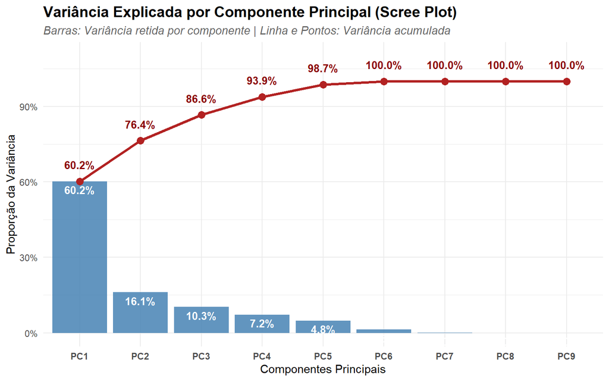

```r
# 1. Execução do PCA com padronização obrigatória
dados_pca_total <- dados %>% select(-Family, -TSH,)
pca_total <- prcomp(dados_pca_total, center = TRUE, scale. = TRUE)

# 2. Cálculos das Proporções de Variância
var_explicada <- pca_total$sdev^2
prop_var <- var_explicada / sum(var_explicada)
var_acumulada <- cumsum(prop_var)

# 3. Criação do Dataframe para o Gráfico
df_pca_var <- data.frame(
  Componente = factor(paste0("PC", 1:length(prop_var)), levels = paste0("PC", 1:length(prop_var))),
  Proporcao = prop_var,
  Acumulada = var_acumulada
)

# 4. Plotagem do Scree Plot com Variância Acumulada
grafico_variancia <- ggplot(df_pca_var, aes(x = Componente)) +
  geom_bar(aes(y = Proporcao), stat = "identity", fill = "steelblue", alpha = 0.85) +
  geom_line(aes(y = Acumulada, group = 1), color = "firebrick", linewidth = 1.2) +
  geom_point(aes(y = Acumulada), color = "firebrick", size = 3) +
  geom_text(aes(y = Acumulada, label = scales::percent(Acumulada, accuracy = 0.1)),
            vjust = -1.5, color = "darkred", size = 3.5, fontface = "bold") +
  geom_text(aes(y = Proporcao, label = scales::percent(Proporcao, accuracy = 0.1)),
            vjust = 1.5, color = "white", size = 3.5, fontface = "bold") +
  scale_y_continuous(labels = scales::percent_format(), limits = c(0, 1.1)) +
  theme_minimal() +
  labs(
    title = "Variância Explicada por Componente Principal (Scree Plot)",
    subtitle = "Barras: Variância retida por componente | Linha e Pontos: Variância acumulada",
    x = "Componentes Principais",
    y = "Proporção da Variância"
  ) +
  theme(
    plot.title = element_text(face = "bold", size = 14),
    plot.subtitle = element_text(face = "italic", color = "gray40"),
    axis.text.x = element_text(face = "bold")
  )

print(grafico_variancia)
```

```r
# Estruturação do banco de dados com os 4 primeiros Componentes Principais
dados_regressao_pcr <- cbind(dados %>% select(TSH), pca_total$x[, 1:4])

# Ajuste do Modelo PCR
modelo_pcr_total <- lm(TSH ~ PC1 + PC2 + PC3 + PC4, data = dados_regressao_pcr)
summary(modelo_pcr_total)
```

```
##
## Call:
## lm(formula = TSH ~ PC1 + PC2 + PC3 + PC4, data = dados_regressao_pcr)
##
## Residuals:
##     Min      1Q  Median      3Q     Max
## -19.177  -5.448  -1.496   5.127  24.546
##
## Coefficients:
##             Estimate Std. Error t value Pr(>|t|)
## (Intercept) 119.0865     1.0486 113.562  < 2e-16 ***
## PC1          -6.0700     0.4542 -13.365  < 2e-16 ***
## PC2           1.1789     0.8778   1.343    0.185
## PC3          11.4882     1.0994  10.449 1.13e-14 ***
## PC4         -13.6804     1.3131 -10.419 1.26e-14 ***
## ---
## Signif. codes:  0 '***' 0.001 '**' 0.01 '*' 0.05 '.' 0.1 ' ' 1
##
## Residual standard error: 8.123 on 55 degrees of freedom
## Multiple R-squared:  0.8786, Adjusted R-squared:  0.8698
## F-statistic: 99.54 on 4 and 55 DF,  p-value: < 2.2e-16
```

Pensando na parcimônia, aplicou-se o algoritimo de seleção de variáveis stepwise sobre o modelo contendo os 4 PC selecionados anteriormente.

```r
# Usando a função step() para fazer a seleção no modelo de componentes
modelo_pcr_refinado <- step(modelo_pcr_total, direction = "both", trace = 0)

# Verificando quais componentes sobreviveram e a nova precisão
summary(modelo_pcr_refinado)
```

```
##
## Call:
## lm(formula = TSH ~ PC1 + PC3 + PC4, data = dados_regressao_pcr)
##
## Residuals:
##     Min      1Q  Median      3Q     Max
## -20.991  -5.856  -1.171   4.310  25.220
##
## Coefficients:
##             Estimate Std. Error t value Pr(>|t|)
## (Intercept) 119.0865     1.0561  112.76  < 2e-16 ***
## PC1          -6.0700     0.4574  -13.27  < 2e-16 ***
## PC3          11.4882     1.1073   10.38 1.18e-14 ***
## PC4         -13.6804     1.3225  -10.35 1.32e-14 ***
## ---
## Signif. codes:  0 '***' 0.001 '**' 0.01 '*' 0.05 '.' 0.1 ' ' 1
##
## Residual standard error: 8.181 on 56 degrees of freedom
## Multiple R-squared:  0.8747, Adjusted R-squared:  0.8679
## F-statistic: 130.3 on 3 and 56 DF,  p-value: < 2.2e-16
```

A aplicação do procedimento Stepwise sobre os componentes principais confirmou a ineficiência preditiva do PC2. O modelo PCR refinado, retendo exclusivamente PC1, PC3 e PC4, manteve a acurácia global praticamente inalterada ($R^2_{adj} = 86,79\%$). Contudo, a remoção do componente ruído provocou um aumento substancial na Estatística F do modelo (de 99,54 para 130,3), evidenciando um ganho expressivo de robustez analítica. O Biplot gerado atesta esta dinâmica: o PC1 isola a variação espectral altamente correlacionada (VIF máximo de 27.366 no NGRDI), enquanto o PC2 mapeia a arquitetura física (SN contraposto a SH e SD), fenômeno de compensação que não reflete em acúmulo de tonelagem (TSH).

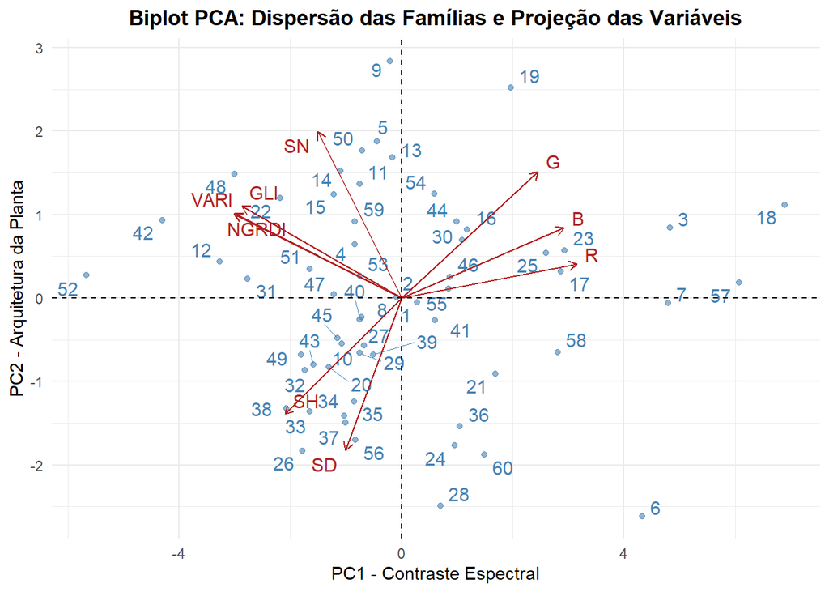

```r
library(factoextra)

# Gerando o Biplot elegante
grafico_biplot <- fviz_pca_biplot(pca_total,
                                  repel = TRUE,                # Evita que os textos se sobreponham
                                  col.var = "firebrick",       # Cor das setas (Variáveis)
                                  col.ind = "steelblue",       # Cor dos pontos (Famílias)
                                  alpha.ind = 0.6,             # Transparência dos pontos
                                  title = "Biplot PCA: Dispersão das Famílias e Projeção das Variáveis",
                                  xlab = paste0("PC1 - Contraste Espectral"),
                                  ylab = paste0("PC2 - Arquitetura da Planta")) +
  theme_minimal() +
  theme(plot.title = element_text(face = "bold", hjust = 0.5))

print(grafico_biplot)
```

Análise de resíduos

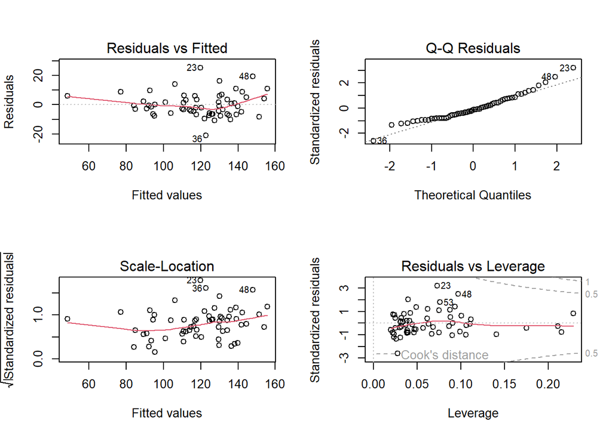

```r
par(mfrow=c(2,2))
plot(modelo_pcr_refinado)
```

```r
library(caret)
library(dplyr)
library(knitr)

set.seed(123)

# 1. Configurando os métodos de Validação Cruzada
controle_kfold <- trainControl(method = "cv", number = 10)
controle_loocv <- trainControl(method = "LOOCV")

# 2. Treinando o modelo com 10-Fold CV
# Usando o modelo refinado: TSH em função dos componentes que sobreviveram
modelo_kfold <- train(
  TSH ~ PC1 + PC3 + PC4,
  data = dados_regressao_pcr,
  method = "lm",
  trControl = controle_kfold
)

# 3. Treinando o modelo com Leave-One-Out (LOOCV)
modelo_loocv <- train(
  TSH ~ PC1 + PC3 + PC4,
  data = dados_regressao_pcr,
  method = "lm",
  trControl = controle_loocv
)

# 4. Extraindo as métricas de cada modelo para comparar
metricas_kfold <- modelo_kfold$results %>% select(RMSE, Rsquared, MAE)
metricas_loocv <- modelo_loocv$results %>% select(RMSE, Rsquared, MAE)

# 5. Criando um Dataframe de comparação
tabela_comparacao <- rbind(
  "10-Fold CV" = metricas_kfold,
  "LOOCV (Deixa um de fora)" = metricas_loocv
)

# 6. Imprimindo a tabela formatada
kable(tabela_comparacao,
      caption = "Comparação de Métricas de Validação Cruzada: 10-Fold vs LOOCV",
      digits = 3,
      align = "c")
```

Comparação de Métricas de Validação Cruzada: 10-Fold vs LOOCV

|  | RMSE | Rsquared | MAE |
| --- | --- | --- | --- |
| 10-Fold CV | 7.713 | 0.855 | 6.403 |
| LOOCV (Deixa um de fora) | 8.458 | 0.857 | 6.551 |

```r
# Carregando os pacotes necessários
library(caret)
library(ggplot2)
library(dplyr)
library(knitr)

# Garantindo a reprodutibilidade da separação dos dados no 10-Fold
set.seed(123)
controle_kfold <- trainControl(method = "cv", number = 10)

# Criando um dataframe vazio para guardar os resultados
resultados_poly <- data.frame(Grau = integer(), RMSE = numeric(), Rsquared = numeric())

# Loop para testar polinômios do Grau 1 ao Grau 4
for (grau in 1:4) {

  # Criando a fórmula dinamicamente para o grau atual
  # Exemplo no grau 2: TSH ~ poly(PC1, 2) + poly(PC3, 2) + poly(PC4, 2)
  formula_poly <- as.formula(paste0("TSH ~ poly(PC1, ", grau, ") + poly(PC3, ", grau, ") + poly(PC4, ", grau, ")"))

  # Treinando o modelo com 10-Fold CV
  modelo_temp <- train(
    formula_poly,
    data = dados_regressao_pcr,
    method = "lm",
    trControl = controle_kfold
  )

  # Guardando as métricas de validação deste grau
  resultados_poly <- rbind(resultados_poly, data.frame(
    Grau = grau,
    RMSE = modelo_temp$results$RMSE,
    Rsquared = modelo_temp$results$Rsquared
  ))
}

# 1. Imprimindo a tabela de comparação no relatório
kable(resultados_poly,
      caption = "Desempenho da Validação Cruzada (10-Fold) por Grau do Polinômio",
      digits = 3, align = "c")
```

Desempenho da Validação Cruzada (10-Fold) por Grau do Polinômio

| Grau | RMSE | Rsquared |
| --- | --- | --- |
| 1 | 7.713 | 0.855 |
| 2 | 8.174 | 0.884 |
| 3 | 11.235 | 0.782 |
| 4 | 11.498 | 0.838 |